# Explore and Summarize Data by WuXuhua

```
## [1] "C"
```

```
##  [1] "X"                    "fixed.acidity"        "volatile.acidity"
##  [4] "citric.acid"          "residual.sugar"       "chlorides"
##  [7] "free.sulfur.dioxide"  "total.sulfur.dioxide" "density"
## [10] "pH"                   "sulphates"            "alcohol"
## [13] "quality"
```

```
##   X fixed.acidity volatile.acidity citric.acid residual.sugar chlorides
## 1 1           7.0             0.27        0.36           20.7     0.045
## 2 2           6.3             0.30        0.34            1.6     0.049
## 3 3           8.1             0.28        0.40            6.9     0.050
## 4 4           7.2             0.23        0.32            8.5     0.058
## 5 5           7.2             0.23        0.32            8.5     0.058
## 6 6           8.1             0.28        0.40            6.9     0.050
##   free.sulfur.dioxide total.sulfur.dioxide density   pH sulphates alcohol
## 1                  45                  170  1.0010 3.00      0.45     8.8
## 2                  14                  132  0.9940 3.30      0.49     9.5
## 3                  30                   97  0.9951 3.26      0.44    10.1
## 4                  47                  186  0.9956 3.19      0.40     9.9
## 5                  47                  186  0.9956 3.19      0.40     9.9
## 6                  30                   97  0.9951 3.26      0.44    10.1
##   quality
## 1       6
## 2       6
## 3       6
## 4       6
## 5       6
## 6       6
```

```
## 'data.frame':    4898 obs. of  12 variables:
##  $ fixed.acidity       : num  7 6.3 8.1 7.2 7.2 8.1 6.2 7 6.3 8.1 ...
##  $ volatile.acidity    : num  0.27 0.3 0.28 0.23 0.23 0.28 0.32 0.27 0.3 0.22 ...
##  $ citric.acid         : num  0.36 0.34 0.4 0.32 0.32 0.4 0.16 0.36 0.34 0.43 ...
##  $ residual.sugar      : num  20.7 1.6 6.9 8.5 8.5 6.9 7 20.7 1.6 1.5 ...
##  $ chlorides           : num  0.045 0.049 0.05 0.058 0.058 0.05 0.045 0.045 0.049 0.044 ...
##  $ free.sulfur.dioxide : num  45 14 30 47 47 30 30 45 14 28 ...
##  $ total.sulfur.dioxide: num  170 132 97 186 186 97 136 170 132 129 ...
##  $ density             : num  1.001 0.994 0.995 0.996 0.996 ...
##  $ pH                  : num  3 3.3 3.26 3.19 3.19 3.26 3.18 3 3.3 3.22 ...
##  $ sulphates           : num  0.45 0.49 0.44 0.4 0.4 0.44 0.47 0.45 0.49 0.45 ...
##  $ alcohol             : num  8.8 9.5 10.1 9.9 9.9 10.1 9.6 8.8 9.5 11 ...
##  $ quality             : int  6 6 6 6 6 6 6 6 6 6 ...
```

```
##  fixed.acidity    volatile.acidity  citric.acid     residual.sugar
##  Min.   : 3.800   Min.   :0.0800   Min.   :0.0000   Min.   : 0.600
##  1st Qu.: 6.300   1st Qu.:0.2100   1st Qu.:0.2700   1st Qu.: 1.700
##  Median : 6.800   Median :0.2600   Median :0.3200   Median : 5.200
##  Mean   : 6.855   Mean   :0.2782   Mean   :0.3342   Mean   : 6.391
##  3rd Qu.: 7.300   3rd Qu.:0.3200   3rd Qu.:0.3900   3rd Qu.: 9.900
##  Max.   :14.200   Max.   :1.1000   Max.   :1.6600   Max.   :65.800
##    chlorides       free.sulfur.dioxide total.sulfur.dioxide
##  Min.   :0.00900   Min.   :  2.00      Min.   :  9.0
##  1st Qu.:0.03600   1st Qu.: 23.00      1st Qu.:108.0
##  Median :0.04300   Median : 34.00      Median :134.0
##  Mean   :0.04577   Mean   : 35.31      Mean   :138.4
##  3rd Qu.:0.05000   3rd Qu.: 46.00      3rd Qu.:167.0
##  Max.   :0.34600   Max.   :289.00      Max.   :440.0
##     density             pH          sulphates         alcohol
##  Min.   :0.9871   Min.   :2.720   Min.   :0.2200   Min.   : 8.00
##  1st Qu.:0.9917   1st Qu.:3.090   1st Qu.:0.4100   1st Qu.: 9.50
##  Median :0.9937   Median :3.180   Median :0.4700   Median :10.40
##  Mean   :0.9940   Mean   :3.188   Mean   :0.4898   Mean   :10.51
##  3rd Qu.:0.9961   3rd Qu.:3.280   3rd Qu.:0.5500   3rd Qu.:11.40
##  Max.   :1.0390   Max.   :3.820   Max.   :1.0800   Max.   :14.20
##     quality
##  Min.   :3.000
##  1st Qu.:5.000
##  Median :6.000
##  Mean   :5.878
##  3rd Qu.:6.000
##  Max.   :9.000
```

```
## [1] "table wine qulity:"
```

```
##
##    3    4    5    6    7    8    9
##   20  163 1457 2198  880  175    5
```

```
## [1] "table wine qulity level:"
```

```
##
##    low middle   high
##    183   3655   1060
```

# Univariate Plots Section

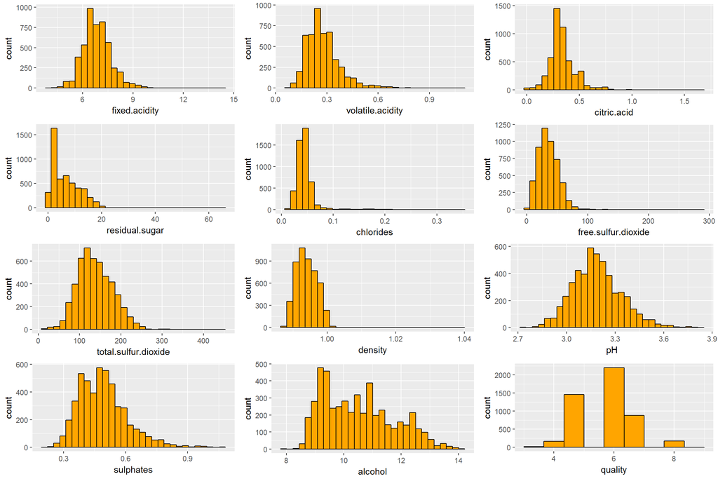

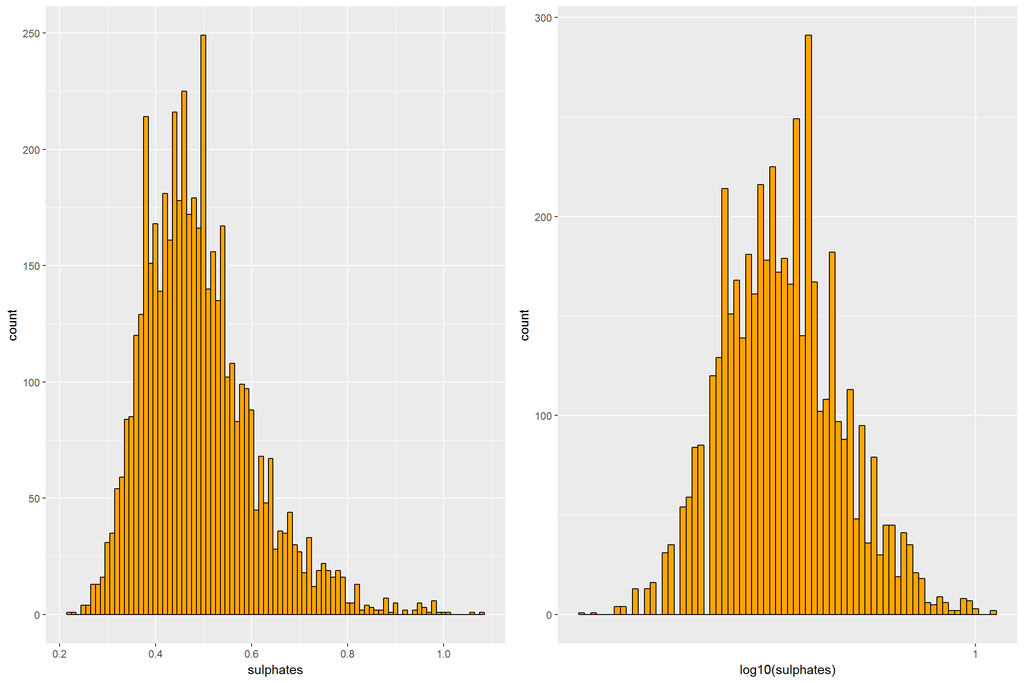

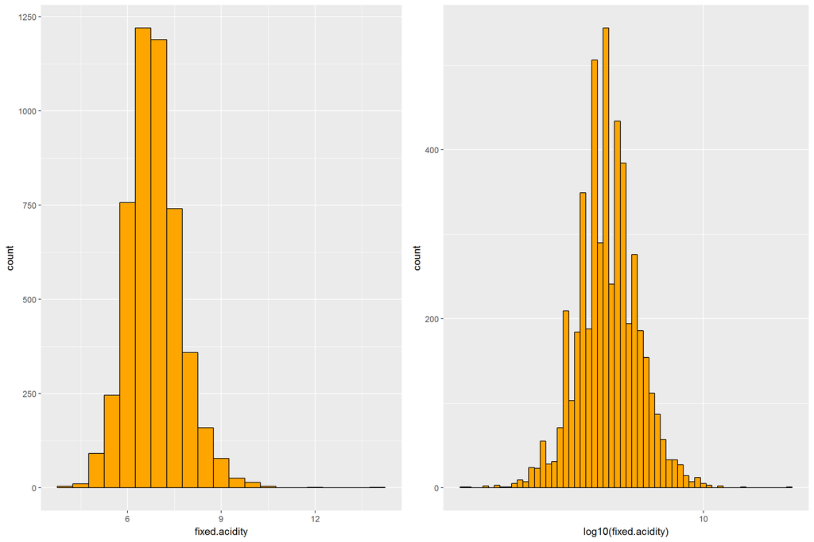

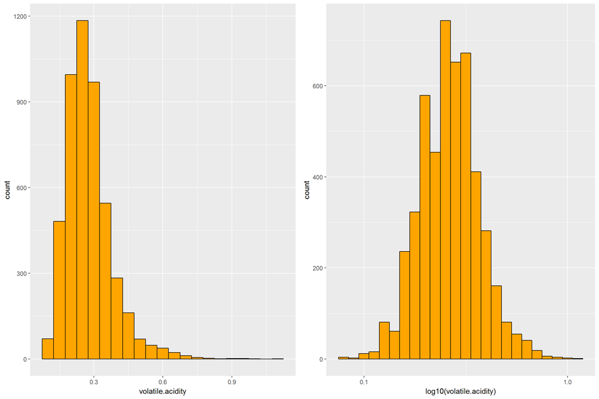

log10转换后，数据更加接近正太分布，方便我们进行分析。

# Univariate Analysis

### What is the structure of your dataset?

总共有4898条白葡萄酒记录，每条记录有11种白葡萄酒的化学属性(fixed.acidity, volatile.acidity, citric.acid, residual.sugar, chlorides, free.sulfur.dioxide, total.sulfur.dioxide, density, pH, sulphates, alcohol)和质量(quality)。 白葡萄酒质量评分的中位数是6，75%的质量评分在6分或以下。酒精含量的中位数是10.4，最高含量是14.2。

### What is/are the main feature(s) of interest in your dataset?

质量是主要特性，我想要知道是哪些因素决定了白葡萄酒质量的好坏。

### What other features in the dataset do you think will help support your investigation into your feature(s) of interest?

我猜测剩余糖量(residual.sugar)、pH值(各种酸混合的结果)、密度(density)和酒精含量起着主要的作用。

### Did you create any new variables from existing variables in the dataset?

我创建了一个新的变量quality.level,他是基于质量得分对质量分配的等级，有3个值(low:3,4)、(middle:5,6)、(high:7,8,9)

### Of the features you investigated, were there any unusual distributions? Did you perform any operations on the data to tidy, adjust, or change the form of the data? If so, why did you do this?

# Bivariate Plots Section

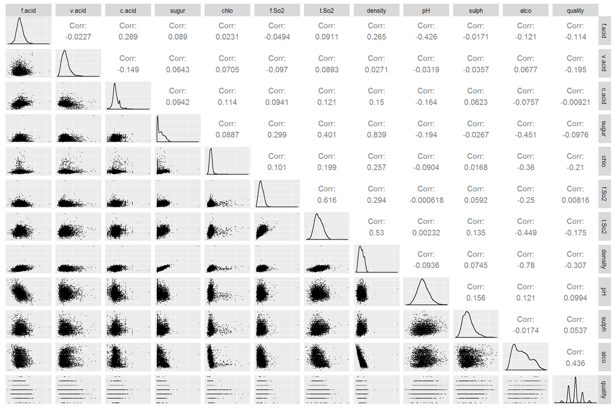

首先来看一下这些数据是否在化学上有其合理性，我首先画一下pH值和固定酸度散点图。相关系数是-0.426，意味着当固定酸度上升时，pH值会下降，符合常理。

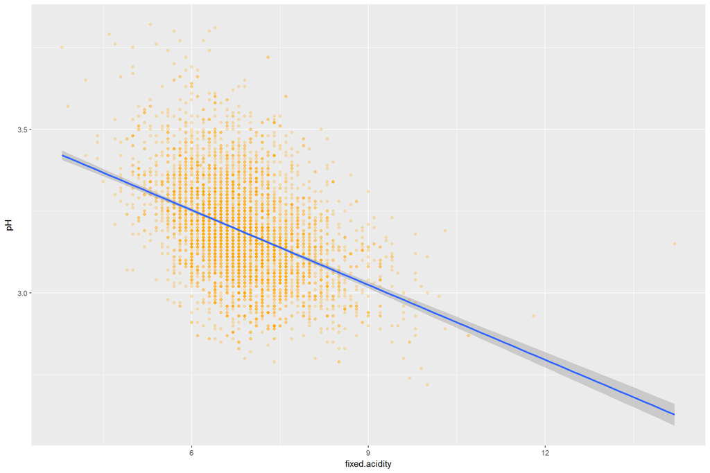

```
##
##  Pearson's product-moment correlation
##
## data:  wine$fixed.acidity and wine$pH
## t = -32.934, df = 4896, p-value < 2.2e-16
## alternative hypothesis: true correlation is not equal to 0
## 95 percent confidence interval:
##  -0.4485154 -0.4026542
## sample estimates:
##        cor
## -0.4258583
```

柠檬酸(citric.acid)和pH值的关系要弱很多，相关系数是-0.164。这也说明了柠檬酸是固定酸度的一个子集。

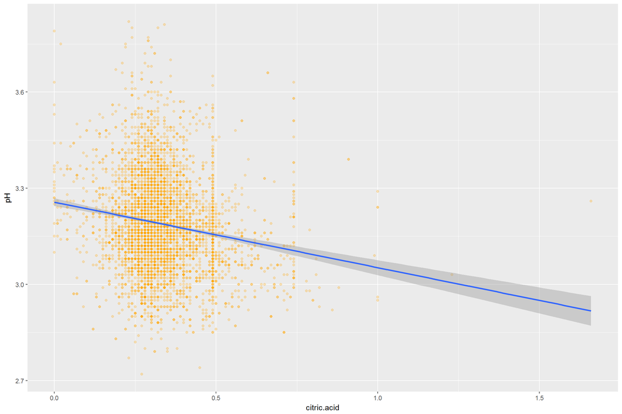

```
##
##  Pearson's product-moment correlation
##
## data:  wine$citric.acid and wine$pH
## t = -11.614, df = 4896, p-value < 2.2e-16
## alternative hypothesis: true correlation is not equal to 0
## 95 percent confidence interval:
##  -0.1908793 -0.1363671
## sample estimates:
##        cor
## -0.1637482
```

我想要进一步探索酒精含量、氯盐(chlorides)、挥发性酸度(volatile.acidity)和密度(density)来了解它们和白葡萄酒质量的关系，因为它们和质量的关系系数接近或者大于0.2。我使用箱线图和中位数来测量数据的差别。箱线图揭示了十分有趣的事实，高质量的白葡萄酒的酒精含量明显高于中等和低质量的酒。氯盐、挥发性酸度和密度和质量呈现了负相关。

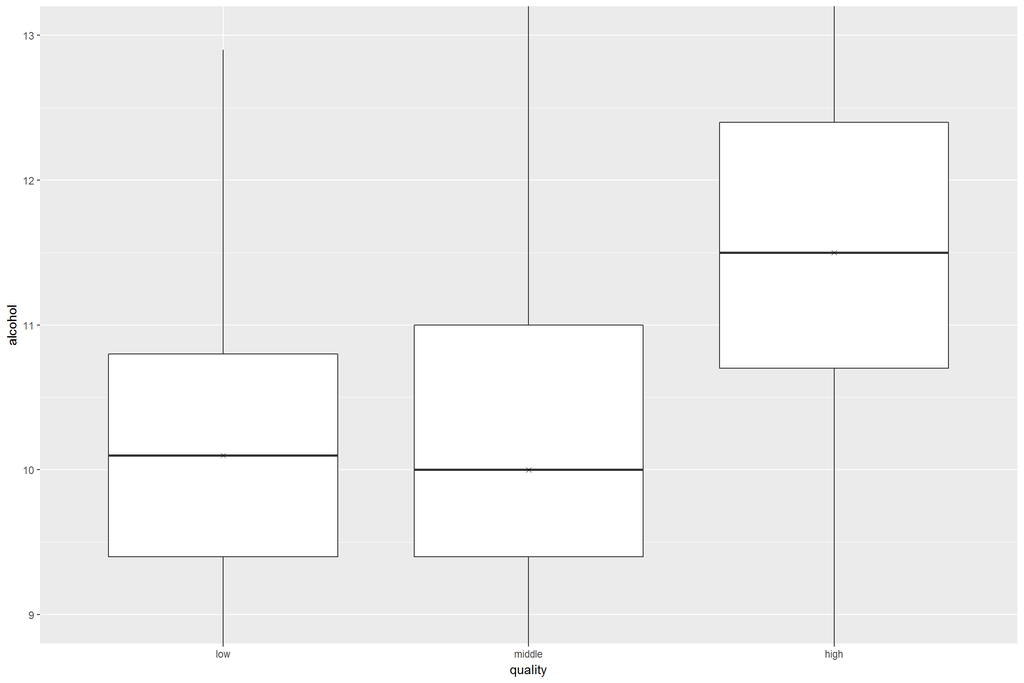

```
## wine$quality.level: low
##    Min. 1st Qu.  Median    Mean 3rd Qu.    Max.
##    8.00    9.40   10.10   10.17   10.80   13.50
## --------------------------------------------------------
## wine$quality.level: middle
##    Min. 1st Qu.  Median    Mean 3rd Qu.    Max.
##    8.00    9.40   10.00   10.27   11.00   14.00
## --------------------------------------------------------
## wine$quality.level: high
##    Min. 1st Qu.  Median    Mean 3rd Qu.    Max.
##    8.50   10.70   11.50   11.42   12.40   14.20
```

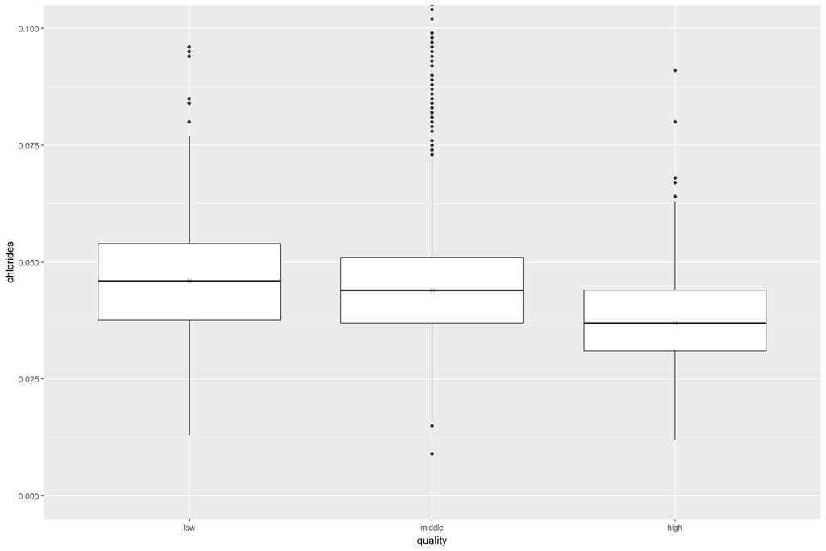

```
## wine$quality.level: low
##    Min. 1st Qu.  Median    Mean 3rd Qu.    Max.
## 0.01300 0.03750 0.04600 0.05056 0.05400 0.29000
## --------------------------------------------------------
## wine$quality.level: middle
##    Min. 1st Qu.  Median    Mean 3rd Qu.    Max.
## 0.00900 0.03700 0.04400 0.04774 0.05100 0.34600
## --------------------------------------------------------
## wine$quality.level: high
##    Min. 1st Qu.  Median    Mean 3rd Qu.    Max.
## 0.01200 0.03100 0.03700 0.03816 0.04400 0.13500
```

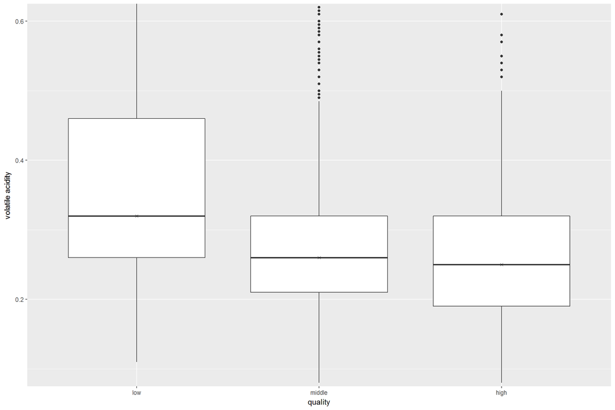

```
## wine$quality.level: low
##    Min. 1st Qu.  Median    Mean 3rd Qu.    Max.
##   0.110   0.260   0.320   0.376   0.460   1.100
## --------------------------------------------------------
## wine$quality.level: middle
##    Min. 1st Qu.  Median    Mean 3rd Qu.    Max.
##  0.0800  0.2100  0.2600  0.2771  0.3200  0.9650
## --------------------------------------------------------
## wine$quality.level: high
##    Min. 1st Qu.  Median    Mean 3rd Qu.    Max.
##  0.0800  0.1900  0.2500  0.2653  0.3200  0.7600
```

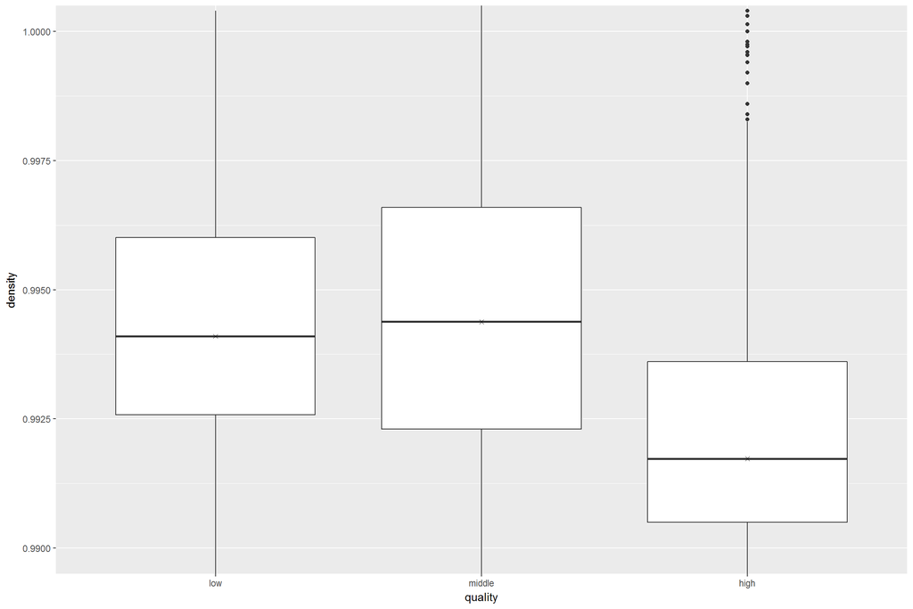

```
## wine$quality.level: low
##    Min. 1st Qu.  Median    Mean 3rd Qu.    Max.
##  0.9892  0.9926  0.9941  0.9943  0.9960  1.0004
## --------------------------------------------------------
## wine$quality.level: middle
##    Min. 1st Qu.  Median    Mean 3rd Qu.    Max.
##  0.9872  0.9923  0.9944  0.9945  0.9966  1.0390
## --------------------------------------------------------
## wine$quality.level: high
##    Min. 1st Qu.  Median    Mean 3rd Qu.    Max.
##  0.9871  0.9905  0.9917  0.9924  0.9936  1.0006
```

# Bivariate Analysis-

### Did you observe any interesting relationships between the other features (not the main feature(s) of interest)?

我观察到剩余糖量和密度的相关性非常高，相关系数是0.839，成很强的正相关，说明糖量会增加白葡萄酒的密度；酒精含量和密码成负相关，相关系数是-0.78，联想到酒精的密度比水低，这一点也就合理了。

### What was the strongest relationship you found?

从散点矩阵图中可以看到，最强的相关性是剩余糖量和密度的关系，相关系数是0.839

# Multivariate Plots Section

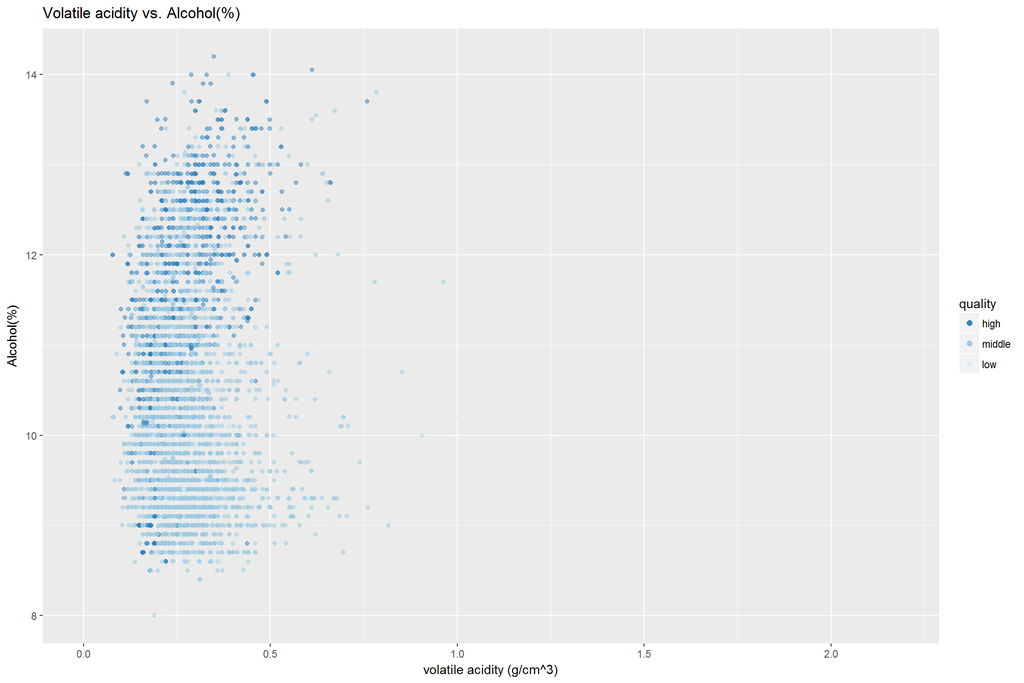

将挥发性酸度和酒精含量比较时，我观察到低质量的白葡萄酒的挥发性酸度值集中在0.3到0.5，中高质量的酒集中在0.2到0.4;中高质量的挥发性酸度相差不大，在这种情况下，酒精含量的高低决定了酒的质量的高低。

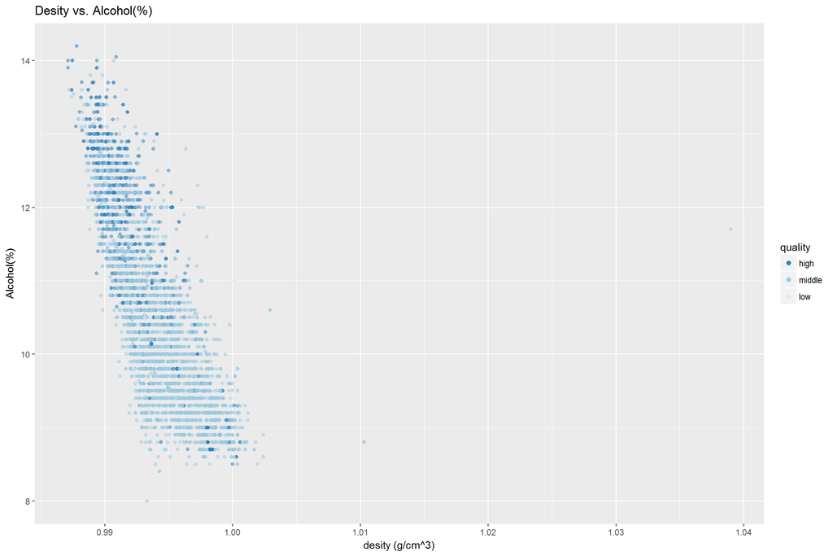

从酒精含量和密度的关系图中可以看到，不同质量的酒的密度范围相差不大，都在0.98到1之间，而且酒精和密度有很强的负相关性；据此可以认为，决定白葡萄酒质量的仍然是酒精含量。

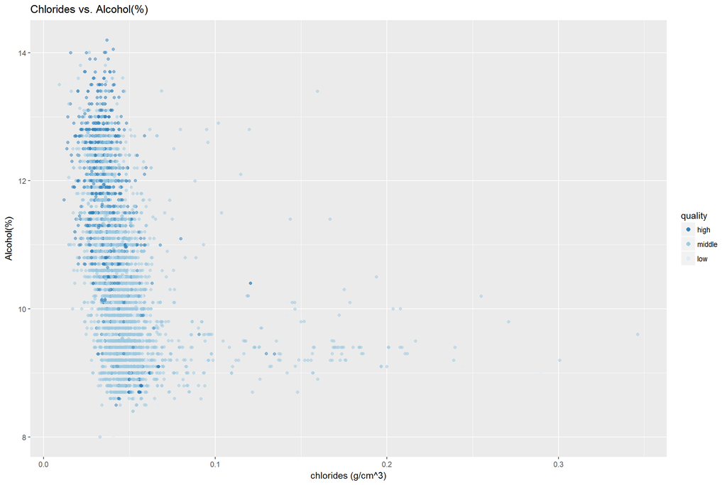

从图中可以看到，高质量的白葡萄酒的氯盐含量略微低于中低档的白葡萄酒，主要集中在0.05值的左侧，但是差别不是很明显，说明相对酒精含量，氯盐的影响要小很多。

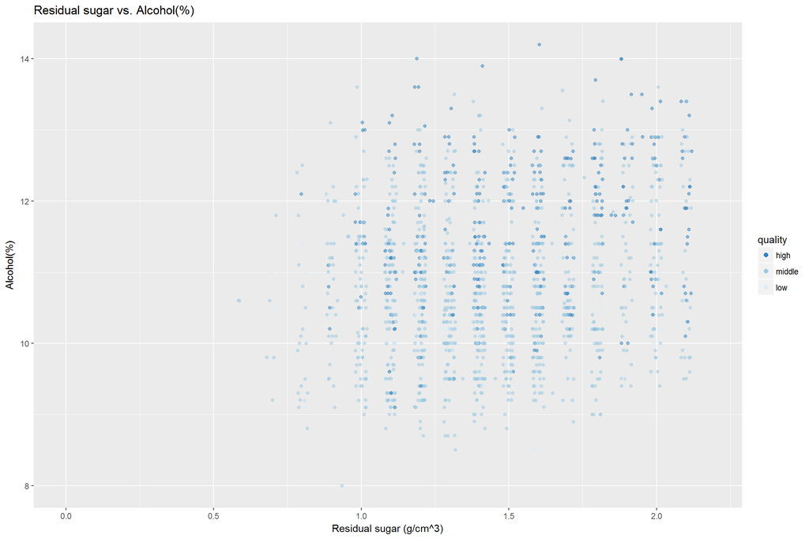

可见剩余糖量对质量的影响不大，高中低质量酒的剩余糖量数据处在同一范围内。

下面我想从密度曲线再来看一下酒精含量和挥发性酸度这两种比较重要的因素的作用。

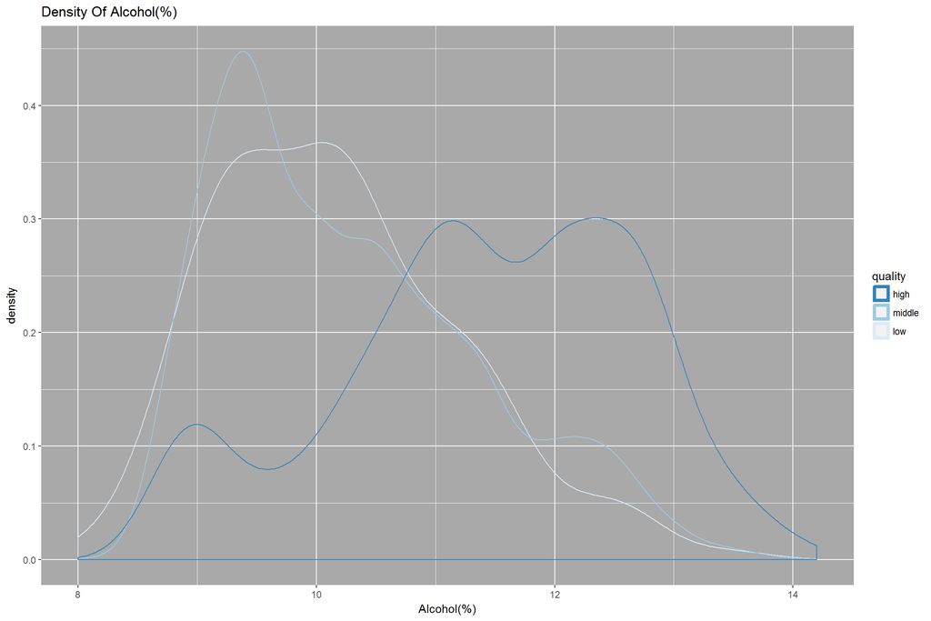

酒精含量密度曲线再次证明了高质量白葡萄酒的酒精含量多于中低质量的白葡萄酒。

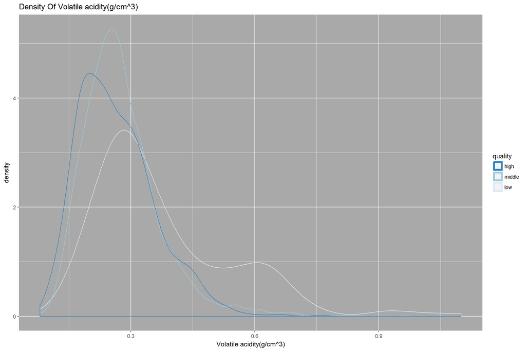

挥发性酸度的密度曲线可以看出，低质量的葡萄酒的挥发性酸度略微高于中高质量的酒，挥发酸度对质量有一定影响，然而在中高质量之间差别不是很明显。

# Multivariate Analysis

### Were there any interesting or surprising interactions between features?

剩余糖量被认为对酒的口味具有主要影响，在数据集中对质量的影响不大，相关系数只有-0.098。

### OPTIONAL: Did you create any models with your dataset? Discuss the strengths and limitations of your model.

# Final Plots and Summary

### Plot One

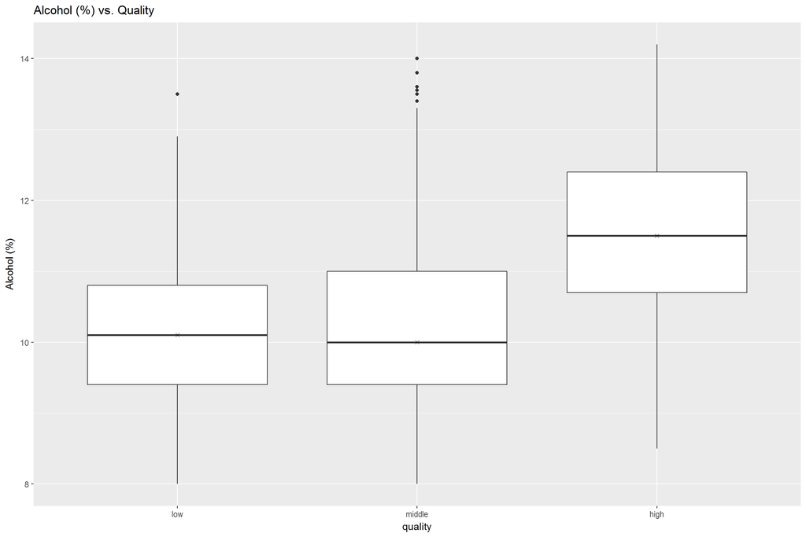

```
## wine$quality.level: low
##    Min. 1st Qu.  Median    Mean 3rd Qu.    Max.
##    8.00    9.40   10.10   10.17   10.80   13.50
## --------------------------------------------------------
## wine$quality.level: middle
##    Min. 1st Qu.  Median    Mean 3rd Qu.    Max.
##    8.00    9.40   10.00   10.27   11.00   14.00
## --------------------------------------------------------
## wine$quality.level: high
##    Min. 1st Qu.  Median    Mean 3rd Qu.    Max.
##    8.50   10.70   11.50   11.42   12.40   14.20
```

### Description One

这张图片显示了高质量的酒通常会包含较高的酒精含量，这符合人们通常以酒精度来衡量酒的好坏的习惯做法。

### Plot Two

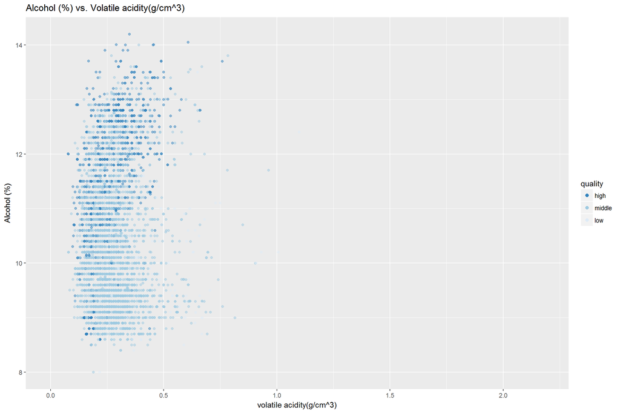

### Description Two

高、中质量的酒和低质量的酒相比，挥发性酸度要低一些，说明挥发性酸度高是低质量酒的特点。在挥发性酸相同的情况下，酒精含量决定了质量的高低。

### Plot Three

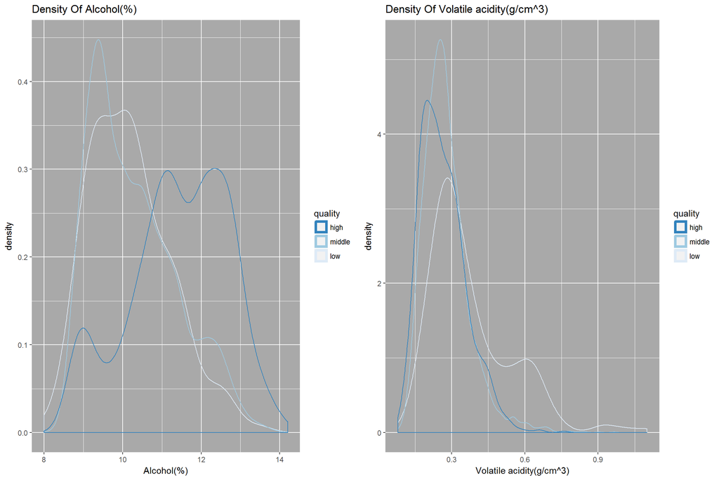

### Description Three

我们观察到高质量酒相反方向的走势。高酒精含量和低挥发性酸度的酒更倾向于被评为高质量的。基于此，我们可以看到高酒精含量和低挥发酸度是白葡萄酒质量的重要指标。

# Reflection

白酒数据集包含4898条数据，总共有12个变量。我从理解单个变量开始，然后探索感兴趣的问题，寻找相关线索，观察各种图形。最终，我从众多变量中探索了决定白葡萄酒质量的因素

目前看来，酒精含量是决定质量的主要因素。挥发性酸度需要达到一定的数量，以便使酒精含量产生作用。也许我们可以将这种情况称之为某种“化学反应”。

虽然说12个变量看起来并不是很多，但也花费了我不少时间去找到真正具有决定因素的变量。值得一提的是，虽然探索变量的过程费时费力，有的时候发现某些变量作用不大的时候也会令人沮丧，但是这还是值得的。因为它们最终缩小了查找的范围，并最终找到了正确的变量。另外，我一开始不知道选择哪种图表来绘制变量好，为了解决这个问题，我列出了能够绘制的图表，并了解它们的特性和作用，并最终选择了适合的图表。